# Ford GoBike System Dataset Exploration

## by (Akbarshox)

## Investigation Overview

## Dataset Overview

> This Dataset contains details of individuals borrowed bikes from a bike-sharing system (called Ford GoBike System) covering the greater San Francisco Bay area.It consists of 15 columns and over 183000 observations.

## Distribution of Length of trip

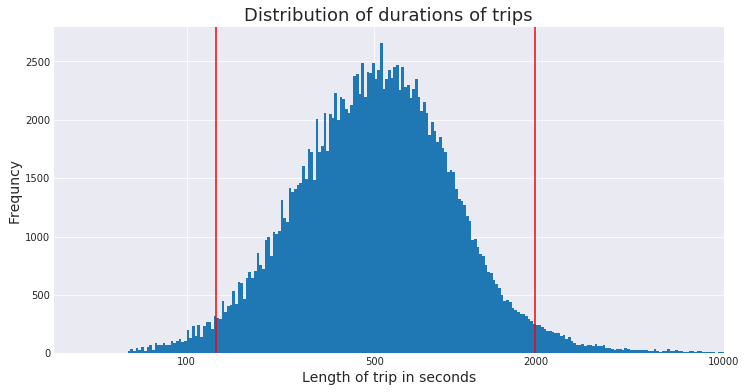

## Distribution of Gender

Pie chart shows that most frequntly rides taken by men (74.6%,130651) and women are in the second place(23.3,40844).We also have third group which is called Other(2.1%,3652),I think they are people about whose gender there is not information.

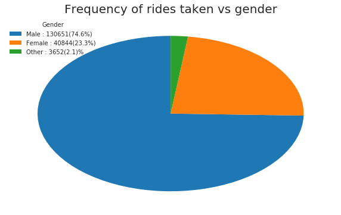

## Average trip duration Vs Gender

The highest average trip length is in other whose gender is not defined with average about 990 seconds ,and in the second place ,it is surprisng,is women with average 790 seconds and last one is men with average 670 seconds.According to this we can conclude that men takes rides more,but not long.

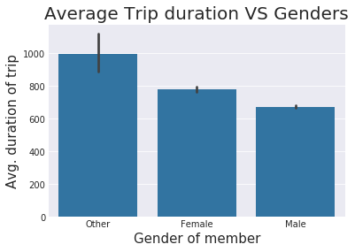

## Average trip duration Vs Days of Week

We can see tha average trip length is higher in weekends both more than 800 seconds ,in weekdays there is not high range of difference all of there are about 680 seconds.I think the reason is that in weekdays more people take bikes to go to work and in weekends just for having a rest from busy life routine

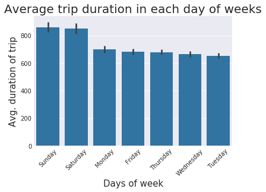

## Average trip duration Vs Days of Week Vs Gender

In this visualization, we can see that the highest overall avegrage is in other and second place for women and last one is men.They all have the same pattern between Monday an Saturday,but in sunday both other and female rise when men fall.

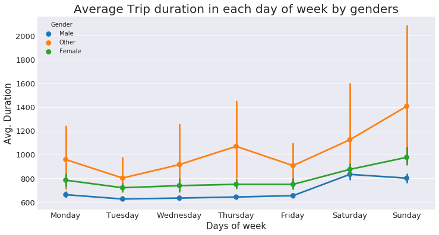

# Thank you for you Attention